# wavFeatExt: Wavelet-based Feature Extraction for Copy Number Alteration Data

Maharani Ahsani Ummi and Arief Gusnanto

16 December 2025

#### Package

wavFeatExt 1.1.4

# 1 Introduction

The **`wavFeatExt`** package implements the methodology proposed by Ummi et al. (2022) for feature extraction from copy-number alteration (CNA) profiles using the non-decimated Haar wavelet transform (NHWT). The main goal is to represent genome-wide CNA signals by multiscale wavelet coefficients that are more suitable for prediction than the raw, highly correlated CNA values.

In typical CNA studies, each sample is measured at thousands of genomic windows (or genes), and neighbouring windows are strongly correlated because CNAs occur in contiguous segments. Directly fitting supervised learning models on these correlated predictors can lead to unstable variable selection and suboptimal classification performance. Wavelet-based feature extraction addresses this by:

- decomposing each CNA profile into detail coefficients (local differences, capturing gains/losses at multiple scales), and
- scaling coefficients (local averages at multiple scales),

which together provide a compact, multiresolution representation of the genome-wide CNA landscape.

The package provides:

- simulation of block-correlated CNA data (**`sim.CNA`**),
- segmentation using circular binary segmentation (**`seg`**, **`CBS`**),
- wavelet-based feature extraction (**`wavFeatExt`**),
- PCA/ICA feature extraction for comparison (**`get.pca`**, **`get.ica`**), and
- classification wrappers for several machine-learning methods (**`classif.wavFeatExt`**, **`classif.pcaica`**).

This vignette gives a short, reproducible example of the wavFeatExt workflow on simulated CNA data, closely mirroring the analyses described in the original paper.

For any query about the package, please contact the maintainer, Maharani A. Ummi (maharaniahsani@itb.ac.id).

## 1.1 Getting Started

Once the package is available on Bioconductor, it can be installed in the usual way:

```r
if (!requireNamespace("BiocManager", quietly = TRUE))
    install.packages("BiocManager")

BiocManager::install("wavFeatExt")
```

Then load the package:

```r
install.packages("C:/Users/maharaniau/OneDrive - University of Leeds/Research/R Programming/Packages/wavFeatExt5/wavFeatExt/wavFeatExt_1.1.4.tar.gz",type="source", repos = NULL)
# Installing package into 'C:/Users/maharaniau/AppData/Local/R/win-library/4.3'
# (as 'lib' is unspecified)
library(wavFeatExt)
```

## 1.2 Input data structure

Most functions in wavFeatExt expect CNA data in the form of a numeric matrix

- rows = samples (patients),
- columns = genomic locations (windows or genes),

or a **list** of such matrices when multiple data sets (e.g. repeated simulations) are analysed.

For real data, a typical preprocessing pipeline is:

1. Align reads and compute depth-of-coverage per genomic window.
2. Normalise coverage (e.g. GC-content, tumour purity).
3. Segment each profile using circular binary segmentation (CBS).

In this vignette we will work with simulated, already segmented data from sim.CNA, which mimics these characteristics.

# 2 Simulation

## 2.1 Simulating CNA data

The function **`sim.CNA()`** generates segmented CNA profiles for two tumour subtypes under a multivariate normal model with a block correlation structure, similar to the simulation study in Ummi et al. (2022).

```r
# One simulated data set with moderate dimension

sim_dat <- sim.CNA(
n.obs     = 80,    # number of samples
p         = 512,   # number of genomic locations
n.sim     = 1,     # number of simulated data sets
effect.diff = 1,   # mean difference between subtypes
n.block   = 32
)
# Simulating data set 1

length(sim_dat)
dim(sim_dat[[1]])
```

[output not shown]

**`sim_dat`** is a list of length **`n.sim`**; each element is an **`n.obs x p`** matrix of segmented CNA values. By construction, the first half of the rows correspond to subtype 1, and the second half to subtype 2.

We now create a binary response factor:

```r
X <- sim_dat[[1]]
n <- nrow(X)

y <- factor(rep(c("Subtype1", "Subtype2"), each = n / 2))
table(y)
```

[output not shown]

## 2.2 Wavelet-based feature extraction

The core function **`wavFeatExt()`** applies the non-decimated Haar wavelet transform across genomic locations for each sample and returns either detail or scaling coefficients at all available scales.

```r
# Extract wavelet detail coefficients (differences)

det_coef <- wavFeatExt(sim_dat, type = "detail")

# Extract wavelet scaling coefficients (averages)

sca_coef <- wavFeatExt(sim_dat, type = "scaling")

length(det_coef)          # number of simulated data sets
length(det_coef[[1]])     # number of scales for detail coefficients
dim(det_coef[[1]][[1]])   # samples x windows at the first scale
```

[output not shown]

For each simulated data set:

**`det_coef[[i]][[m]]`** is the matrix of detail coefficients at scale m,

**`sca_coef[[i]][[m]]`** is the corresponding matrix of scaling coefficients.

Each matrix has the same dimension as the original CNA data (**`n.obs x p`**). At fine scales, detail coefficients represent differences between nearby windows; at coarser scales, they summarise changes over longer genomic regions.

## 2.3 Visualising wavelet coefficients for a single profile

For illustrative purposes, we can inspect the NHWT coefficients of a single CNA profile using the legacy helper **`nhwt()`** and **`plot.nhwt()`**. This is a convenient way to see how the transform behaves on one sample.

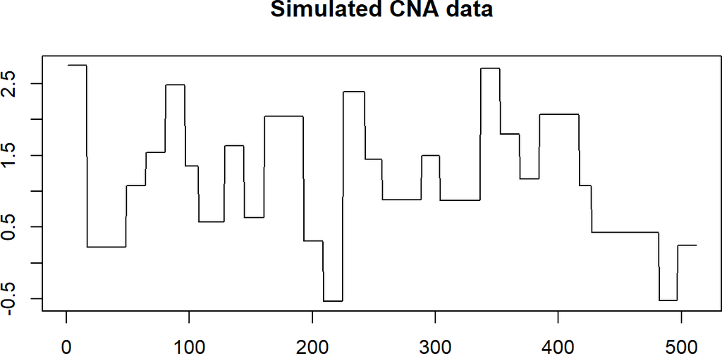

```r
# Take one sample (row) from the simulated data

x1 <- X[1, ]

# Non-decimated Haar transform (detail coefficients)

nh_detail <- nhwt(x1, type = "detail")
nh_scaling <- nhwt(x1, type = "scaling")

# Plot coefficients by scale
plot(x1, type="l", xlab="", ylab="", main="Simulated CNA data")
```

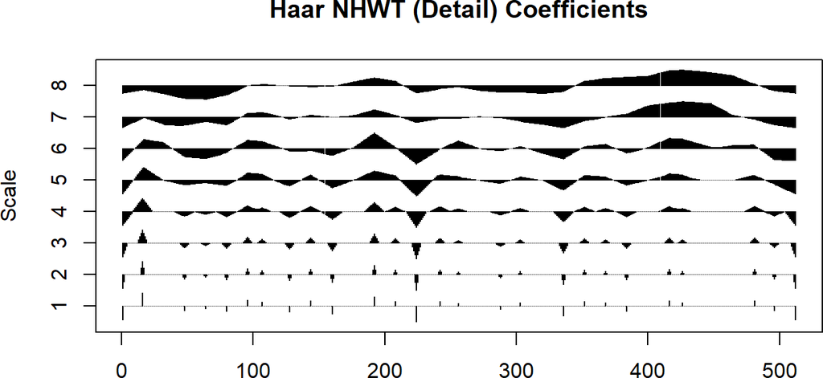

```r
plot(nh_detail, coef = "detail", type = "by.level", scale = "all")
```

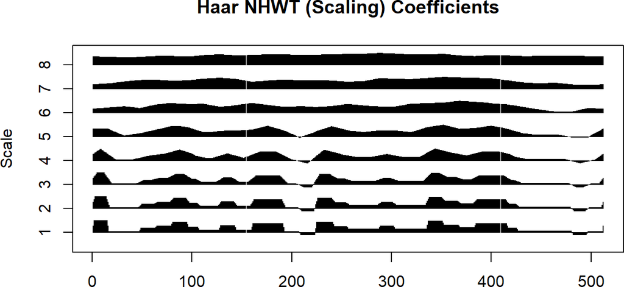

```r
plot(nh_scaling, coef = "scaling", type = "by.level", scale = "all")
```

## 2.4 Classification using wavelet features

After extracting wavelet coefficients, the **`classif.wavFeatExt()`** function provides a unified interface to several machine-learning classifiers implemented in **`glmnet`**, **`randomForest`**, **`nnet`**, **`pls`**, and **`class`**. The function accepts:

- **`data`** – a list of CNA matrices or simulated CNA output
- **`y`** – a factor of class labels
- **`det`** – list of wavelet detail coefficients
- **`sca`** – list of wavelet scaling coefficients
- **`method`** – **`"lasso"`**, **`"elnet"`**, **`"RF"`**, **`"NN"`**, **`"PLS"`**, or **`"KNN"`**
- **`k`** – number of folds for cross-validation
- **`ite`** – number of datasets to evaluate (defaults to all)

Below is an example classification based on wavelet detail coefficients:

```r
# Extract wavelet detail coefficients (differences)

det_coef <- wavFeatExt(sim_dat, type = "detail")

# Extract wavelet scaling coefficients (averages)

sca_coef <- wavFeatExt(sim_dat, type = "scaling")

# Binary response (for example, first 40 vs last 40 samples)
y <- factor(c(rep("Group1", 40), rep("Group2", 40)))

# Perform classification using Lasso
res_lasso <- classif.wavFeatExt(sim_dat, y, det=det_coef, sca=sca_coef,
                          method = "lasso", k = 5, ite = 2)
```

The output typically contains:

- Numeric matrix of cross-validated misclassification errors,
- Numeric matrix of cross-validated areas under the ROC curve,
- the classification method used.